# MultiEnvironmentTrial

#### 6.2.0.4 Deal with the missing data

As described above, if missing values can be grouped into line:environment sets that are 100% missing, these sets can be dropped from the model and only predicted from the posterior of other parameters. The following code attempts to find an optimal partitioning of values to maximize the number of dropped NA values in the smallest number of groups

```r
maps = make_Missing_data_map(MegaLMM_state,max_NA_groups = ncol(Y)+1,verbose=F)
maps$map_results
```

| map | N_groups | max_group_size | total_kept_NAs |
| --- | --- | --- | --- |
| 1 | 1 | 502 | 6797 |
| 2 | 3 | 373 | 3914 |
| 3 | 4 | 319 | 2300 |
| 4 | 5 | 296 | 1744 |
| 5 | 6 | 296 | 1517 |
| 6 | 7 | 296 | 1143 |
| 7 | 8 | 296 | 869 |
| 8 | 9 | 296 | 677 |
| 9 | 10 | 296 | 611 |
| 10 | 11 | 296 | 561 |

[output cut: 9 more lines]

Using the 15th map above might be a good option:

```r
MegaLMM_state = set_Missing_data_map(MegaLMM_state,maps$Missing_data_map_list[[15]])
```

#### 6.2.0.5 Initialize the model object

Next, we create random starting values for all parameters:

```r
MegaLMM_state = initialize_variables_MegaLMM(MegaLMM_state)
```

```
[1] "initializing Lambda_prec horseshoe"
[1] "initializing B_prec horseshoe"
```

### 6.2.1 Initialize parameters and posterior database

Now, we need to calculate some matrices that `MegaLMM` will use repeatedly during the Gibbs sampler. These calculations can take quite a bit of time for large models, particular when there are a lot of individuals, more than 1 random effect, and many groups of traits from the missing data map.

#### 6.2.1.1 Memory usage

The stored matrices can also use a lot of RAM. It is a good idea to first get an estimate of how much RAM the model will need, before jumping in to the calculations. We can estimate the memory usage using the following function:

```r
estimate_memory_initialization_MegaLMM(MegaLMM_state)
```

```
[1] "Random effects: Line"
[1] "16 groups of traits and 20 h2 grid cells"
[1] "Estimated initialized size: 0.01 B Gb"
```

Because this dataset is small and there is only 1 random effect, the memory requirements are low.

#### 6.2.1.2 Pre-calculate useful matrices

Now we can run these preliminary calculations:

```r
MegaLMM_state = initialize_MegaLMM(MegaLMM_state,verbose = T)
```

```
[1] "Pre-calculating random effect inverse matrices for 16 groups of traits and 20 sets of random effect weights"
```

#### 6.2.1.3 Prepare the Posterior database

As described above, the `MegaLMM` has many parameters, and we could store posterior samples of all parameters. But there’s not much use in storing large parameter arrays if we’re not actually interested in the values of those parameters.

Also, sometimes our interest is not really in *any* of the parameters, but instead in some function we can calculate from a set of parameters. For example, we’re interested in `U`, the additive genetic values, or `Y` the genetic values, but those are not parameters of our `MegaLMM` model. We could store all parameters and then calculated these predicted values at the end, but that would be a waste of space.

Instead, we can control which specific parameters are stored by the program.

By default, `MegaLMM` stores individual posterior samples of some parameters, and posterior means of others. You can see the list of defaults here:

These parameters have individual samples stores:

```r
MegaLMM_state$Posterior$posteriorSample_params
```

```
 [1] "Lambda"       "U_F"          "F"            "delta"        "tot_F_prec"   "F_h2"         "tot_Eta_prec"
 [8] "resid_h2"     "B1"           "B2_F"         "B2_R"         "U_R"          "cis_effects"  "Lambda_m_eff"
[15] "Eta"
```

These parameters have only posterior means stores:

```r
MegaLMM_state$Posterior$posteriorMean_params
```

```
[1] "Eta_mean"
```

`Eta_mean` is the internal parameter for the predicted phenotypic value `Y`.

In our case, many of these values are not useful, so I’ll re-specify these lists:

```r
MegaLMM_state$Posterior$posteriorSample_params = c('Lambda','F_h2','resid_h2','tot_Eta_prec')
MegaLMM_state$Posterior$posteriorMean_params = 'Eta_mean'
```

But we also want to calculate the predicted genetic values. From the `MegaLMM` model, the predicted genetic values are the combination of the genetic component of `Y_R` (`U_R`), and the genetic component of `F` (`U_F`) rotated by the factor loadings:

`U = U_F * Lambda + U_R`

We can ask `MegaLMM` to calculate this value for us and save the posterior samples. I’ve also included code to calculate the genetic (**G**) and residual (**R**) covariances among environments, and the additive heritability of each environment because they might be interesting.

```r
MegaLMM_state$Posterior$posteriorFunctions = list(
  U = 'U_F %*% Lambda + U_R',
  G = 't(Lambda) %*% diag(F_h2[1,]) %*% Lambda + diag(resid_h2[1,]/tot_Eta_prec[1,])',
  R = 't(Lambda) %*% diag(1-F_h2[1,]) %*% Lambda + diag((1-resid_h2[1,])/tot_Eta_prec[1,])',
  h2 = '(colSums(F_h2[1,]*Lambda^2)+resid_h2[1,]/tot_Eta_prec[1,])/(colSums(Lambda^2)+1/tot_Eta_prec[1,])'
  )
```

Now that we’ve decided which values to save, we initialize the posterior database:

```r
MegaLMM_state = clear_Posterior(MegaLMM_state)
```

As a final check, we should also assess how much memory the posterior samples will require.

We can estimate with the `estimate_memory_posterior()` function, giving it a number of iterations we plan to run **in a single chunk (see below)**.

```r
estimate_memory_posterior(MegaLMM_state,100)
```

```
[1] "Estimated posterior size for n_samples: Inf Gb"
```

## 6.3 Run the MCMC and diagnose convergence

We’re finally ready to fit the model! Fitting the means running the Gibbs sampler. This is accomplished with the `sample_MegaLMM()` function, which takes a `MegaLMM_state` object and the number of iterations to run as arguments. We do run the chain in two stages: `burnin` and `sampling`.

#### 6.3.0.1 Burnin

The burnin period is a period we wait until the chain comes to the stationary distribution. We can either wait a defined number of steps, or we can monitor convergence diagnostics, such as trace plots.

I prefer to use trace plots of the parameters that I am interested in. Yes it is not completely safe to declare stationarity until all parameters are stationary, but especially when we are only interested in the posterior mean of something like breeding values or genetic covariance, this seems to work well, and correlations across replicate runs is generally high.

While Gibbs samplers will eventually reach the stationary distribution, it is OK during the burnin phase to use some deliberate artificial jumps to push the chain into a location that likely has higher posterior mass. The one place that I’ve found this useful is in the order of the factors. Factor order is very sticky in the chain - it can take hundreds of iterations for any factor to switch. This means that factor order will never achieve a high effective sample size from this Gibbs sampler. However, I find that if I periodically check the observed importance of each factor during the burnin phase and then re-sort the factors, I achieve convergence of other parameters much more readily.

Therefore, my recommended manual burnin goes through a few rounds of:

#### 6.3.0.2 Collect posterior samples

If we think the model is reasonable converged to stationary, we can now collect posterior samples.

Since we’re not going to collect a lot of samples, and we’re not storing large matrices, we could do this in one run. But I’m still going to do it in a few chunks to demonstrate the `save_posterior_chunk()` function which saves the posterior samples to the database on disk, clears the posterior samples in memory, and continues sampling. We then load the samples we want back at the end.

```r
n_iter = 250
for(i in 1:10) {
  print(sprintf('Sampling run %d',i))
  MegaLMM_state = sample_MegaLMM(MegaLMM_state,n_iter)
  MegaLMM_state = save_posterior_chunk(MegaLMM_state)
  print(MegaLMM_state)
}
```

```
[1] "Sampling run 1"

Time difference of 6.532523 secs

 Current iteration: 1250, Posterior_samples: 125
 Total time: 34.15723 secs

[1] "Sampling run 2"

Time difference of 7.200946 secs

 Current iteration: 1500, Posterior_samples: 250
 Total time: 41.35818 secs

[1] "Sampling run 3"

Time difference of 7.055873 secs

 Current iteration: 1750, Posterior_samples: 375
 Total time: 48.41405 secs

[1] "Sampling run 4"

Time difference of 6.909984 secs

 Current iteration: 2000, Posterior_samples: 500
 Total time: 55.32404 secs

[1] "Sampling run 5"

Time difference of 6.700428 secs

 Current iteration: 2250, Posterior_samples: 625
 Total time: 1.033741 mins

[1] "Sampling run 6"

Time difference of 6.910065 secs

 Current iteration: 2500, Posterior_samples: 750
```

[output cut: 14 more lines]

```
 Total time: 1.379969 mins

[1] "Sampling run 9"

Time difference of 6.938602 secs

 Current iteration: 3250, Posterior_samples: 1125
 Total time: 1.495613 mins

[1] "Sampling run 10"

Time difference of 6.975251 secs

 Current iteration: 3500, Posterior_samples: 1250
 Total time: 1.611867 mins
```

#### 6.3.0.3 Calculate predicted values and other posterior statistics

```r
dim(MegaLMM_state$Posterior$Lambda)
```

```
[1]  0 15 19
```

```r
dim(MegaLMM_state$Posterior$U)
```

```
[1]   0 502  19
```

This is because the `save_posterior_chunk` function saves the samples to the disk. The posterior database is in the folder: `MegaLMM_fold_01/Posterior/*`. To reload samples of a particular parameter, use:

```r
Lambda_samples = load_posterior_param(MegaLMM_state,'Lambda')
U_samples = load_posterior_param(MegaLMM_state,'U')
dim(U_samples)
```

```
[1] 1250  502   19
```

We can get posterior means with the `get_posterior_mean()` function:

```r
U_hat = get_posterior_mean(U_samples)
```

`U_hat` is our predicted additive genetic value for every line in every trial.

We can also access the predicted total genetic value `Eta_mean`, which we stored as a posterior mean instead of as individual samples during the chain:

```r
Eta_mean = load_posterior_param(MegaLMM_state,'Eta_mean')
```

# 7 Estimate Genomic Prediction accuracy

Let’s compare the accuracy of `MegaLMM's` predictions (`U_hat` or `Eta_mean`) to those of `rrBLUP`:

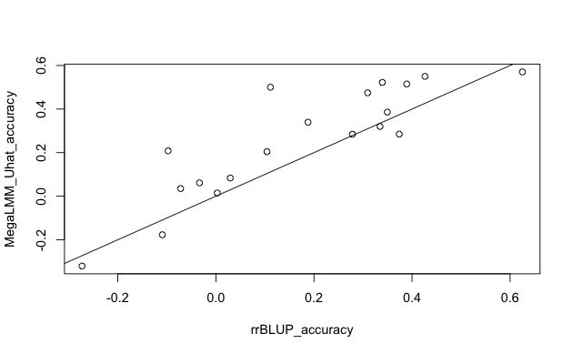

```r
rrBLUP_accuracy = diag(cor(Y_testing,rrBLUP_predictions,use='p'))
MegaLMM_Uhat_accuracy = diag(cor(Y_testing,U_hat,use='p'))
MegaLMM_Eta_mean_accuracy = diag(cor(Y_testing,Eta_mean,use='p'))
plot(rrBLUP_accuracy,MegaLMM_Uhat_accuracy);abline(0,1)
```

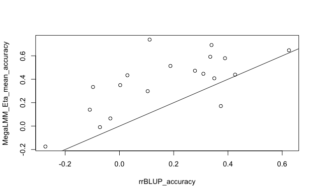

```r
plot(rrBLUP_accuracy,MegaLMM_Eta_mean_accuracy);abline(0,1)
```

We see that in most trials we gained considerable accuracy through the multi-trait modeling.

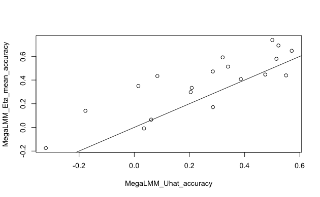

```r
plot(MegaLMM_Uhat_accuracy,MegaLMM_Eta_mean_accuracy);abline(0,1)
```

We also see that because `MegaLMM` can also look at non-additive-genetic covariances among lines (*i.e.* residual correlations that are not explained by `K` but still must be genetic), we generally gained a bit of additional accuracy.

# 8 Additional package details

You can get a summary of the MCMC chain with the `print` and `summary` methods:

```r
print(MegaLMM_state)
```

[output not shown]

```r
summary(MegaLMM_state)
```

```
 Model dimensions: factors = 15, fixed = 2, regression_R = 0, regression_F = 0, random = 502
  Current iteration: 5000, Posterior_samples: 1250
 Total time: 2.38122 mins
```

### 8.0.1 Working with the posterior samples

As I mentioned above, posterior samples can be saved to the disk like this:

```r
MegaLMM_state = save_posterior_chunk(MegaLMM_state)
```

When you do this, you no longer have direct access to the samples you’ve collected inside the `MegaLMM_state` object. Instead, they are stored in the folder: `[run_ID]/Posterior/` where `[run_ID]` is the name you gave to this model run above.

```r
dim(MegaLMM_state$Posterior$Lambda)
```

```
[1]  0 15 19
```

To load all posterior samples of a particular parameter back into `MegaLMM_state` so that you can work with them, you can either call:

```r
U = load_posterior_param(MegaLMM_state,'U')
dim(U)
```

```
[1] 1250  502   19
```

or you can reload all samples of all stored parameers with:

```r
MegaLMM_state$Posterior = reload_Posterior(MegaLMM_state)
dim(MegaLMM_state$Posterior$Lambda)
```

```
[1] 1250   15   19
```

```r
dim(MegaLMM_state$Posterior$F_h2)
```

```
[1] 1250    1   15
```

To assess convergence of a parameter, it’s helpful to look at traceplots. You make a traceplot of a single parameter by extracting its chain and plotting it:

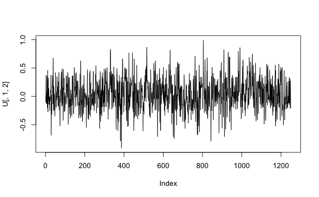

```r
plot(U[,1,2],type='l')
```

But it’d take a lot to make this plot for every element of every matrix. As a shortcut, the function `traceplot_array` can make lots of traceplots for a matrix parameter:

```r
traceplot_array(MegaLMM_state$Posterior$Lambda,facet_dim = 2,name = 'Lambda')
```

This will create a pdf booklet stored in the `[run_ID]` folder (*note in the next update, this will be changed to directly use the file name provided*). This will take the rows (`facet_dim=2`) or columns (`facet_dim=3`) of the provided parameter array and make a faceted plot, where within each facet a sampling of the values in that row/column will be selected (those with the largest posterior means) and traceplots will be made. Generally it is the largest values that are the most interesting, and will be most diagnostic of sampling issues.

Often we want to calculate summaries of the posterior samples. Two functions are provided:

```r
U_hat = get_posterior_mean(U)
dim(U_hat)
```

```
[1] 502  19
```

```r
U_HPD = get_posterior_HPDinterval(U,prob = 0.95)
dim(U_HPD)
```

```
[1]   2 502  19
```

The latter function will calculate lower and upper 0.95 Highest Posterior Density bounds for each element of the matrix `U`.

Finally, we can calculate functions of the parameters, as long as all are stored in the Posterior database. For example, we can calculate the phenotypic covariance matrix at each posterior sample like this:

```r
P_samples = get_posterior_FUN(MegaLMM_state,t(Lambda) %*% Lambda + diag(1/tot_Eta_prec[1,]))
dim(P_samples)
```

```
[1] 1250   19   19
```

### 8.0.2 Extracting random effect covariances

We’ve focused on predicting location effects of the random effects of line for each trait (yield in each environment). But we can also extract the estimates and posterior distributions on the key variance-covariance parameters $\mathbf{G}$ and $\mathbf{R}$. The model for the genetic covariance in MegaLMM is: $\mathbf{G} = \mathbf{\Lambda^T \Sigma_{h^2_F} \Lambda} + \mathbf{\Psi \otimes \Sigma_{h^2_R}}$

We can calculate this using the same syntax:

```r
G_samples = get_posterior_FUN(MegaLMM_state,
              t(Lambda) %*% diag(F_h2[1,]) %*% Lambda + diag(resid_h2[,1]/tot_Eta_prec[1,])
            )
dim(G_samples)
```

```
[1] 1250   19   19
```

But, if you look back, we actually defined this as one of the `posterior_functions` we specifed in the beginning, so it’s actually already calculated for us, and we can just load the samples of this matrix directly:

```r
G_samples = load_posterior_param(MegaLMM_state,'G')
R_samples = load_posterior_param(MegaLMM_state,'R')
dim(G_samples)
```

```
[1] 1250   19   19
```

```r
dim(R_samples)
```

```
[1] 1250   19   19
```

### 8.0.3 Extending the chain

If you look at your posterior samples and decide that the model hasn’t really converged, you can treat the current chain as an extended burnin and re-start the collection of posterior samples. I won’t run the code here so we don’t lose our current samples!

```r
#MegaLMM_state2 = clear_Posterior(MegaLMM_state)
#print(MegaLMM_state2)
```

You’ll see the `Posterior_samples` value has been set to 0.

### 8.0.4 Saving the model object

Our current model object is not that big, and so you can save it directly:

```r
saveRDS(MegaLMM_state,file = 'MegaLMM_state_run_01.rds')
```

And then come back and reload it and go:

```r
MegaLMM_state = readRDS('MegaLMM_state_run_01.rds')
print(MegaLMM_state)
```

```
 Current iteration: 1500, Posterior_samples: 500
 Total time: 44.00336 secs
```

However, to re-start the sampling, all you actually need is the initialized `MegaLMM_state` object with a stored `current_state` slot and the posterior database in the `Posterior` slot. The first slot is a list with the current state of all parameters as well as the random number generator. This gets automatically saved in the `[run_ID]` directory, so you can re-run the `setup_model_MegaLMM()` function, add priors, initialize, etc, and then reload the `current_state` and resume the chain where you left off. The second is a list with the posterior matrices and associated information that gets saved as `Posterior/Posterior_base.rds`. You can load base like this:

```r
MegaLMM_state$current_state = readRDS(file.path(MegaLMM_state$run_ID,'current_state.rds'))
MegaLMM_state$Posterior = readRDS(file.path(MegaLMM_state$run_ID,'Posterior/Posterior_base.rds'))
```

### 8.0.5 Convergence issues

You may have noticed in some diagnostics that parameters of `Lambda` do seem to be drifting a lot, suggesting that the chain has not converged. This suggests you should probably run this model much longer. That is probably true. However, in my experience, posterior distributions of location effects like `U` do not change much with much longer chains - what’s happening is that the magnitude of values of `Lambda` and the magnitude of corresponding columns of `F` are not identified in the likelihood, because the true term in the model is `F * Lambda`. So there’s a lot of drift (poor mixing) in the magnitudes of those parameters, ever if their product is mixing well. Also, the order of columns of F (and rows of Lambda) is not identified in the likelihood. The prior does provide a fairly clear ordering, but it’s still not unusual to have factors switch order. When this happens, `Lambda[1,3]` may take on the previous identity of `Lambda[2,3]` and so traceplots of `Lambda[1,3]` will not look good (or posterior means of this parameter. Therefore, I advise caution interpreting Lambda.